# Factors affecting house Prices

## by Abel Keya

# Investigation Overview

This investigation aims at finding out the factors that affect house price. It mainly focuses on the varying house prices with factors such as location, size in square feet,style and years

# What is the structure of your dataset?

> (6028, 7) The dataset analysed includes information about house prices and factors influencing.The dataset contains 6028 records, and 7 columns.

# What is/are the main feature(s) of interest in this dataset?

- price

# What features in the dataset will help support investigation into your feature(s) of interest?

- price - Price of the house
- bedrooms - Number of Bedrooms
- bathrooms - Number of Bathrooms
- style-the archtectural style of the house
- Neighborhood-the surroundig area where the house located.

# Distribution of house area and price

Both area and price are skewed to the left, changing the bin size has no effect on the shape of the distribution

```
array([1. , 1.5, 2. , 2.5, 3. , 3.5, 4. , 4.5, 5. , 5.5, 6. , 6.5])
```

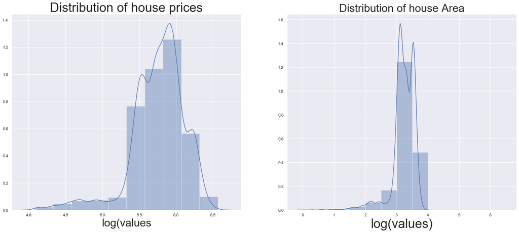

```python
#sns.distplot for houseprice area and price
plt.figure(figsize = [25, 10])
plt.subplot(1, 2, 1)
log_data = np.log10(houseprice['price']) # direct data transform
log_bin_edges = np.arange(5, log_data.max()+0.5, 0.1)
sns.distplot(log_data, bins = 10)
plt.xlabel('log(values',fontsize=(30))
plt.title('Distribution of house prices',fontsize=(35))
plt.subplot(1,2,2)
log_data2 = np.log10(houseprice['area']) # direct data transform
log_bin_edges = np.arange(1, int(log_data.max()+1), 0.5)
sns.distplot(log_data2, bins =log_bin_edges)
plt.xlabel('log(values)',fontsize=(35))
plt.title('Distribution of house Area',fontsize=(30))
log_bin_edges
```

# Total Counts of Bathroomscounts per house

Observing the counts on the plot reveals that most houses have 2 bathrooms which is an indication that 2 bathroomed houses are the most popular while 5 bathrooms per house have the lowest count indicating they are less popular

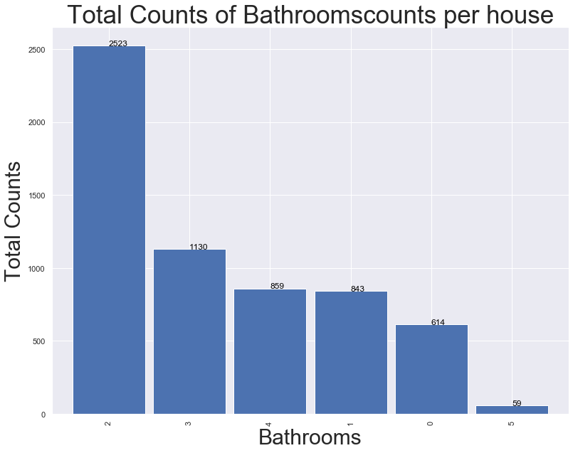

```python
# countplot to for bathrooms
# plot to show the categories of house bedrooms
#counting the values per category
bathrooms = houseprice['bathrooms'].value_counts()
ax=bathrooms.plot.bar(width=.9)
#for loop to iterative over the counts object
for i, v in bathrooms.reset_index().iterrows():
    ax.text(i, v.bathrooms + 0.5 , v.bathrooms, color='black')
plt.title('Total Counts of Bathroomscounts per house', fontsize=35)
plt.xlabel('Bathrooms',fontsize=(30))
plt.ylabel('Total Counts',fontsize=(30))
```

# Total Counts of Bedrooms per house

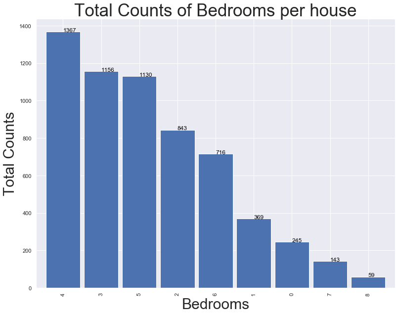

```python
# plot to show the categories of house bedrooms
#counting the values per category
bedrooms = houseprice['bedrooms'].value_counts()
ax=bedrooms.plot.bar(width=.9)
#for loop to iterative over the counts object
for i, v in bedrooms.reset_index().iterrows():
    ax.text(i, v.bedrooms + 0.2 , v.bedrooms, color='black')
plt.title('Total Counts of Bedrooms per house', fontsize=35)
plt.xlabel('Bedrooms',fontsize=(30))
plt.ylabel('Total Counts',fontsize=(30))
```

# Proportions of Styles

The tabulation of the house styles shows three main house styles, the Victorian Style is the most popular with the highest percentage approximately 50%,Ranch is the second most popular house styles with approximately 29.9% Lodge style is least popular accounting to approximately 20.4 %

[figure not shown]

|  | Name of Style | Count | percent |
| --- | --- | --- | --- |
| 0 | victorian | 2997 | 49.72 |
| 1 | ranch | 1802 | 29.89 |
| 2 | lodge | 1229 | 20.39 |

```python
fig, ax = plt.subplots(1, 2,figsize=(16,8))
sns.countplot(y = houseprice['style'], ax=ax[0]).set_title('Count of styles',color='k',fontsize=(35))
labels=houseprice['style'].unique()
colors = ['steelblue','c','lightgrey']
plt.pie(houseprice['style'].value_counts(),labels = labels, colors=colors ,shadow = True,startangle=60, explode = (0.2, 0.01, 0.01), autopct = '%1.1f%%')
plt.axis('equal',fontsize=(30))
plt.title("Percentage Proportions of Styles",fontsize=(35))
plt.legend(labels=['victorian', 'ranch', 'lodge'])
plt.show()
#calculating the total percentage of our each neighborhood
Style = houseprice['style'].value_counts().to_frame().reset_index()
Style['percent'] = Style["style"].apply(lambda x : round(100*float(x) / len(houseprice), 2))
Style = Style.rename(columns = {"index" : "Name of Style", "style" : "Count"})
Style
```

# Distribution of Neighborhood

The dataset has three neighborhoods, Neighborhood B is the most popular with the highest percentage representation at approximately 40.26%,Neighborhood A follows with approximately 31 % while Neighborhood C is the least popular with approximately 28.6%.

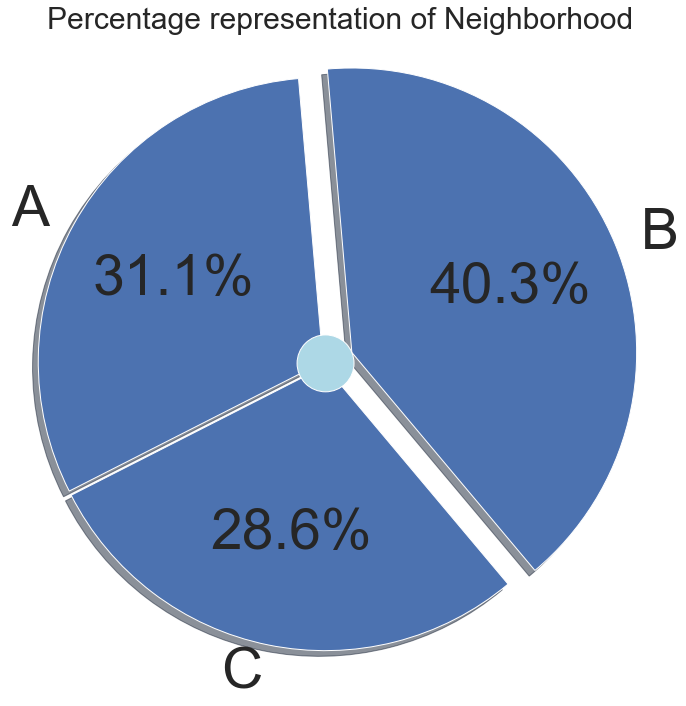

|  | Name of Neighborhood | Count | percent |
| --- | --- | --- | --- |
| 0 | B | 2427 | 40.26 |
| 1 | A | 1876 | 31.12 |
| 2 | C | 1725 | 28.62 |

```python
# create the plot
fig, ax = plt.subplots(figsize=(10,10))
labels=houseprice['neighborhood'].unique()
colors = ['b','b','b']
flavor_pie = ax.pie(houseprice['neighborhood'].value_counts(),labels=labels, autopct='%.1f%%', shadow=True, colors=colors,
explode = (0.1, 0.01, 0.01), startangle= -50
                    , textprops={'fontsize':57})
centre_circle = plt.Circle((0,0),0.10,fc='lightblue')
plt.title('Percentage representation of Neighborhood',fontsize=30)
fig = plt.gcf()
fig.gca().add_artist(centre_circle)
ax.axis('equal')
plt.tight_layout()
plt.show()

# calculating the total percentage of our each neighborhood
neigh = houseprice['neighborhood'].value_counts().to_frame().reset_index()
neigh['percent'] = neigh["neighborhood"].apply(lambda x : round(100*float(x) / len(houseprice), 2))
neigh = neigh.rename(columns = {"index" : "Name of Neighborhood", "neighborhood" : "Count"})
neigh
```

# price Vs Area

Observing the plot of price against area shows that there is a positive correlation between prices and area high variablity in lower values

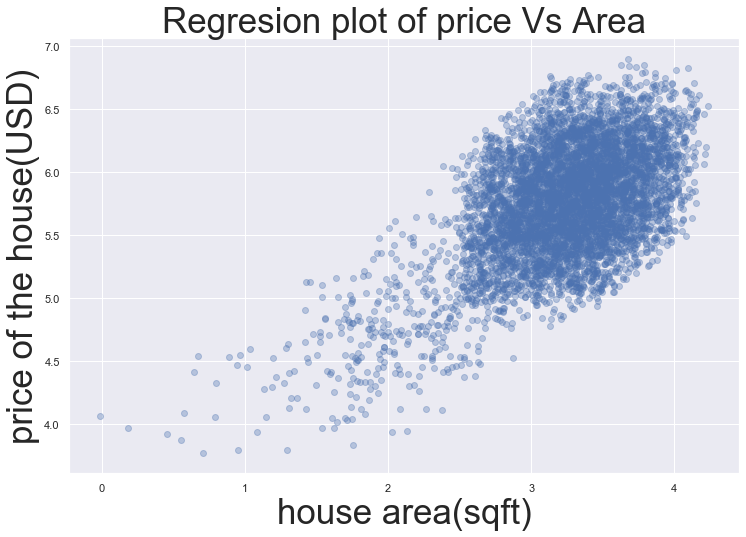

```python
plt.figure(figsize = [12, 8])
#the x- and y- values sent to regplot are set directly as Series, extracted from the dataframe.
sns.regplot(data=houseprice,x=houseprice['area'].apply(log_trans),y= houseprice['price'].apply(log_trans),fit_reg=True,x_jitter = 0.5, y_jitter = 0.5, scatter_kws = {'alpha' : 1/3
})
#sns.regplot(data=houseprice,x= 'area',y= 'price',fit_reg=True)
plt.xlabel('house area(sqft)',fontsize=35)
plt.ylabel('price of the house(USD)',fontsize=35)
plt.title('Regresion plot of price Vs Area',fontsize=35)
#plt.subtitle('')
```

# Price versus bedrooms

The house prices increases with the increase int the number of bedrooms, with the 8 bedrooms having the highest price figure while 1 bedroom has the lowest.This is surprising because the houses with 0 bedroom have higher prices compared to the 1 bedroom house

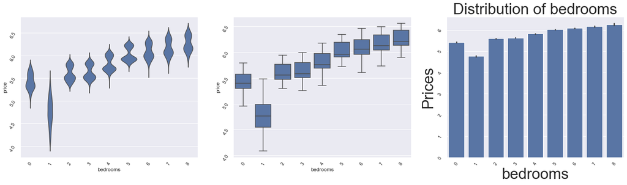

```python
plt.figure(figsize = [25, 6])
base_color = sns.color_palette()[0]

#transform the data data in y axis
def log_trans(y, inverse = False):
    if not inverse:
        return np.log10(y)
    else:
        return np.power(10, y)
# left plot: violin plot
plt.subplot(1, 3, 1)
sns.violinplot(data = houseprice, x = 'bedrooms', y= houseprice['price'].apply(log_trans), inner = None,
              color = base_color)
plt.xticks(rotation = 60) # include label rotation due to small subplot size
plt.yticks(rotation = 60)
# center plot: box plot
plt.subplot(1, 3, 2)
sns.boxplot(data = houseprice, x = 'bedrooms', y= houseprice['price'].apply(log_trans), color = base_color)
plt.xticks(rotation = 60)
plt.yticks(rotation = 60)
# right plot: adapted bar chart
plt.subplot(1, 3, 3)
sns.barplot(data = houseprice, x = 'bedrooms',y= houseprice['price'].apply(log_trans), color = base_color)
plt.xticks(rotation = 60)
plt.yticks(rotation = 60)
plt.title('Distribution of bedrooms',fontsize=(35))
plt.xlabel('bedrooms',fontsize=(35))
plt.ylabel('Prices',fontsize=(35))
```

# Distribution of Bedrooms Vs Neighborhood

The number of bedrooms per house has a normal distribution in all neighborhoods, 4 bedroomed houses have the highest frequency in every neighborhood 8 bedroom house has the lowest frequency in all neighborhoods

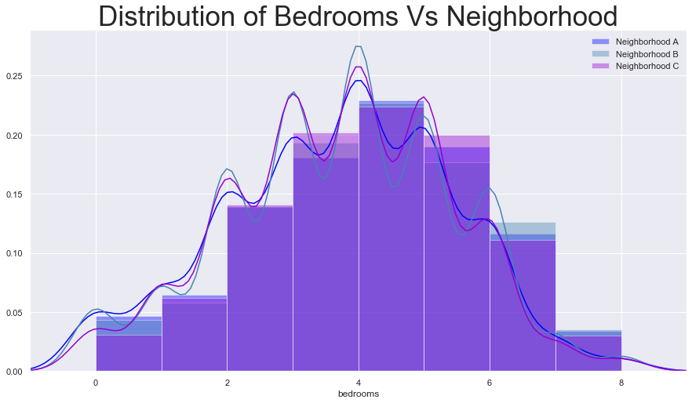

```python
# density plot to show the distribution of the number of bedrooms per house in each neighborhood
plt.figure(figsize=(15,8))
sns.distplot(houseprice[houseprice['neighborhood'] == "A"]['bedrooms'], color='blue',bins =8)
sns.distplot(houseprice[houseprice['neighborhood'] == "B"]['bedrooms'], color='steelblue',bins =8)
sns.distplot(houseprice[houseprice['neighborhood'] == "C"]['bedrooms'], color='darkviolet',bins =8)
plt.title('Distribution of Bedrooms Vs Neighborhood', fontsize=35)
plt.legend(labels=['Neighborhood A', 'Neighborhood B', 'Neighborhood C'])
plt.xlim([-1,9])
plt.show()
```

# Distribution of styles against Neighborhood

Neighborhood B has the highest proportion for all the styles while has the lowest,Victorian style has the highest highest representation while lodge has the lowest representation

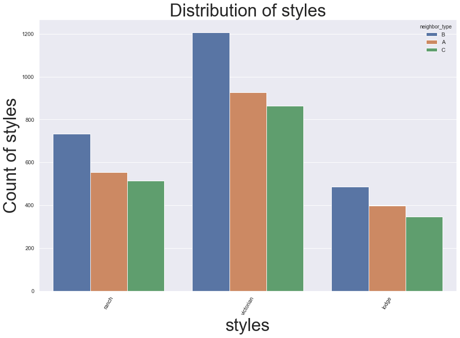

```python
houseprice['neighbor_type']=houseprice['neighborhood'].apply(lambda x: x.split()[0])
style_counts=houseprice.groupby(['style','neighborhood']).size()
style_counts=style_counts.reset_index(name='count')
style_counts.pivot(index='style',columns='neighborhood',values='count')
style_counts.isna().sum()
plt.figure(figsize = [15, 10]);
sns.countplot(data=houseprice,x='style',hue='neighbor_type')
plt.xticks(rotation=60)
plt.title('Distribution of styles',fontsize=35)
plt.xlabel('styles',fontsize=35)
plt.ylabel('Count of styles',fontsize=35)
```

# Distribution of bedrooms against Style

```
Tabulation of the number of bedrooms per style
```

| bedrooms | style | 0 | 1 | 2 | 3 | 4 | 5 | 6 | 7 | 8 |
| --- | --- | --- | --- | --- | --- | --- | --- | --- | --- | --- |
| 0 | lodge | 245.0 | 369.0 | 460.0 | 118.0 | 37.0 | 0.0 | 0.0 | 0.0 | 0.0 |
| 1 | ranch | 0.0 | 0.0 | 350.0 | 730.0 | 645.0 | 77.0 | 0.0 | 0.0 | 0.0 |
| 2 | victorian | 0.0 | 0.0 | 33.0 | 308.0 | 685.0 | 1053.0 | 716.0 | 143.0 | 59.0 |

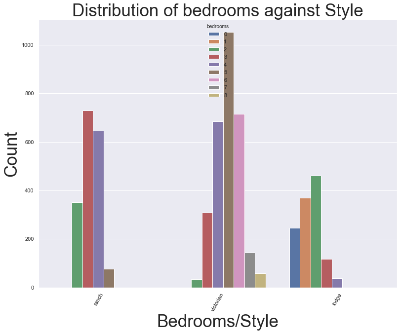

```python
sns.countplot(data=houseprice,x='style',hue='bedrooms')
plt.xticks(rotation=60)
plt.title('Distribution of bedrooms against Style',fontsize=(35))
plt.xlabel('Bedrooms/Style',fontsize=35)
plt.ylabel('Count',fontsize=35)
#
#
#
#Tabulation of the number of bedrooms per style
print('Tabulation of the number of bedrooms per style')
bedrooms_counts=houseprice.groupby(['style','bedrooms']).size()
bedrooms_counts=bedrooms_counts.reset_index(name='count')
bedrooms_counts=bedrooms_counts.pivot(index='style',columns='bedrooms',values='count').fillna(0).reset_index()
bedrooms_counts
```

# Comparison of price/area against Number of bedrooms

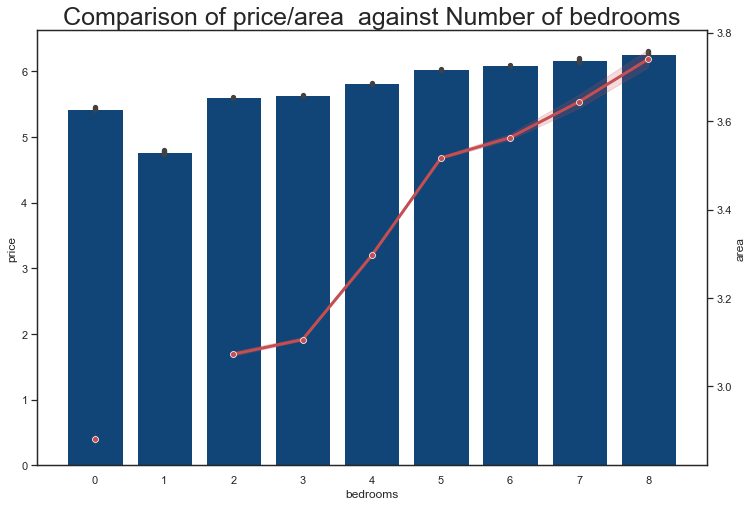

```python
#cobined barplot/line plot for the price and area compared with numbers of bedrooms
sns.set(style="white", rc={"lines.linewidth": 3})
#transform the data data in y axis
def log_trans(y, inverse = False):
    if not inverse:
        return np.log10(y)
    else:
        return np.power(10, y)
fig, ax1 = plt.subplots(figsize=(12,8))
ax2 = ax1.twinx()
sns.barplot(x=houseprice['bedrooms'],
            y=houseprice['price'].apply(log_trans),
            color='#004488',
            ax=ax1)
sns.lineplot(x=houseprice['bedrooms'],
             y=houseprice['area'].apply(log_trans),
             color='r',
             marker="o",
             ax=ax2)
plt.title('Comparison of price/area  against Number of bedrooms',fontsize=25)
plt.show()
sns.set()
```

# Regresion plot of price Vs Area

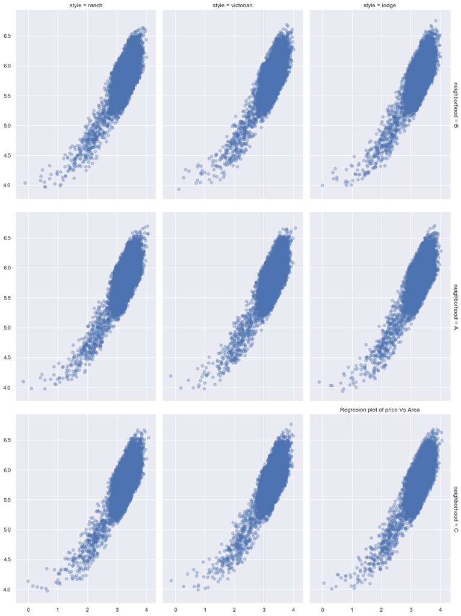

```python
plt.figure(figsize = [25, 10])
#transform the data data in x axis
def log_trans(x, inverse = False):
    if not inverse:
        return np.log10(x)
    else:
        return np.power(10, x)
#transform the data data in y axis
def log_trans(y, inverse = False):
    if not inverse:
        return np.log10(y)
    else:
        return np.power(10, y)

g = sns.FacetGrid(data = houseprice, col = 'style', row = 'neighborhood',height=6,aspect=0.75,margin_titles = True)
plt.xlabel('house area(sqft)')
plt.ylabel('price of the house(USD)')
plt.title('Regresion plot of price Vs Area')
g.map(sns.regplot,data = houseprice,x=houseprice['area'].apply(log_trans), y= houseprice['price'].apply(log_trans),x_jitter = 0.2, y_jitter = 0.2, scatter_kws = {'alpha' : 1/3
})
```